# Traffic Predictions

Data 621 Final

Tommy Jenkins, Violeta Stoyanova, Todd Weigel, Peter Kowalchuk, Eleanor R-Secoquian, Anthony Pagan

2019/12/04

## Utility functions

From R Cookbooks to create multi-panel plots.

## OVERVIEW

In this competition, Kaggle is challenging you to build a model that predicts the total ride duration of taxi trips in New York City. Your primary dataset is one released by the NYC Taxi and Limousine Commission, which includes pickup time, geo-coordinates, number of passengers, and several other variables.

The competition dataset is based on the 2016 NYC Yellow Cab trip record data made available in Big Query on Google Cloud Platform. The data was originally published by the NYC Taxi and Limousine Commission (TLC). The data was sampled and cleaned for the purposes of this playground competition. Based on individual trip attributes, participants should predict the duration of each trip in the test set.

File descriptions

- train.csv - the training set (contains 1458644 trip records)
- test.csv - the testing set (contains 625134 trip records)
- sample_submission.csv - a sample submission file in the correct format

Data fields

id - a unique identifier for each trip * vendor_id - a code indicating the provider associated with the trip record * pickup_datetime - date and time when the meter was engaged * dropoff_datetime - date and time when the meter was disengaged * passenger_count - the number of passengers in the vehicle (driver entered value) * pickup_longitude - the longitude where the meter was engaged * pickup_latitude - the latitude where the meter was engaged * dropoff_longitude - the longitude where the meter was disengaged * dropoff_latitude - the latitude where the meter was disengaged * store_and_fwd_flag - This flag indicates whether the trip record was held in vehicle memory before sending to the vendor because the vehicle did not have a * connection to the server - Y=store and forward; N=not a store and forward trip * trip_duration - duration of the trip in seconds

## Objective:

# DATA EXPLORATION

## Load data

### View Data

```
## Observations: 1,458,644
## Variables: 11
## $ id                 <chr> "id2875421", "id2377394", "id3858529", "id350467...
## $ vendor_id          <int> 2, 1, 2, 2, 2, 2, 1, 2, 1, 2, 2, 2, 2, 2, 2, 1, ...
## $ pickup_datetime    <chr> "2016-03-14 17:24:55", "2016-06-12 00:43:35", "2...
## $ dropoff_datetime   <chr> "2016-03-14 17:32:30", "2016-06-12 00:54:38", "2...
## $ passenger_count    <int> 1, 1, 1, 1, 1, 6, 4, 1, 1, 1, 1, 4, 2, 1, 1, 1, ...
## $ pickup_longitude   <dbl> -73.98215, -73.98042, -73.97903, -74.01004, -73....
## $ pickup_latitude    <dbl> 40.76794, 40.73856, 40.76394, 40.71997, 40.79321...
## $ dropoff_longitude  <dbl> -73.96463, -73.99948, -74.00533, -74.01227, -73....
## $ dropoff_latitude   <dbl> 40.76560, 40.73115, 40.71009, 40.70672, 40.78252...
## $ store_and_fwd_flag <chr> "N", "N", "N", "N", "N", "N", "N", "N", "N", "N"...
## $ trip_duration      <int> 455, 663, 2124, 429, 435, 443, 341, 1551, 255, 1...
```

We also calculate the counts for NA’s, 0, negative, and unique values.

## Data Summary

```
##  [1] "id"                 "vendor_id"          "pickup_datetime"
##  [4] "dropoff_datetime"   "passenger_count"    "pickup_longitude"
##  [7] "pickup_latitude"    "dropoff_longitude"  "dropoff_latitude"
## [10] "store_and_fwd_flag" "trip_duration"
```

```
## [1] "id"                 "vendor_id"          "pickup_datetime"
## [4] "passenger_count"    "pickup_longitude"   "pickup_latitude"
## [7] "dropoff_longitude"  "dropoff_latitude"   "store_and_fwd_flag"
```

## Reformating features

For our following analysis, we will turn the data and time from characters into *date* objects. We also recode *vendor_id* as a factor. This makes it easier to visualise relationships that involve these features.

```
## Observations: 2,083,778
## Variables: 12
## $ id                 <chr> "id2875421", "id2377394", "id3858529", "id350467...
## $ vendor_id          <int> 2, 1, 2, 2, 2, 2, 1, 2, 1, 2, 2, 2, 2, 2, 2, 1, ...
## $ pickup_datetime    <chr> "2016-03-14 17:24:55", "2016-06-12 00:43:35", "2...
## $ dropoff_datetime   <chr> "2016-03-14 17:32:30", "2016-06-12 00:54:38", "2...
## $ passenger_count    <int> 1, 1, 1, 1, 1, 6, 4, 1, 1, 1, 1, 4, 2, 1, 1, 1, ...
## $ pickup_longitude   <dbl> -73.98215, -73.98042, -73.97903, -74.01004, -73....
## $ pickup_latitude    <dbl> 40.76794, 40.73856, 40.76394, 40.71997, 40.79321...
## $ dropoff_longitude  <dbl> -73.96463, -73.99948, -74.00533, -74.01227, -73....
## $ dropoff_latitude   <dbl> 40.76560, 40.73115, 40.71009, 40.70672, 40.78252...
## $ store_and_fwd_flag <chr> "N", "N", "N", "N", "N", "N", "N", "N", "N", "N"...
## $ trip_duration      <int> 455, 663, 2124, 429, 435, 443, 341, 1551, 255, 1...
## $ dset               <fct> train, train, train, train, train, train, train,...
```

### Abnormal Data

### Missing values

```
##               columns na_count neg_count zero_count unique_count
## 1                  id        0         0         NA      2083778
## 2           vendor_id        0         0          0            2
## 3     pickup_datetime        0         0         NA      1926217
## 4    dropoff_datetime   625134        NA         NA      1380378
## 5     passenger_count        0         0         83           10
## 6    pickup_longitude        0   2083778          0        24960
## 7     pickup_latitude        0         0          0        48068
## 8   dropoff_longitude        0   2083778          0        36977
## 9    dropoff_latitude        0         0          0        67086
## 10 store_and_fwd_flag        0         0         NA            2
## 11      trip_duration   625134        NA         NA         7418
## 12               dset        0        NA          0            2
```

```
##               columns na_count neg_count zero_count unique_count
## 1                  id        0         0         NA      2083778
## 2           vendor_id        0         0          0            2
## 3     pickup_datetime        0         0         NA      1926217
## 4    dropoff_datetime   625134        NA         NA      1380378
## 5     passenger_count        0         0         83           10
## 6    pickup_longitude        0   2083778          0        24960
## 7     pickup_latitude        0         0          0        48068
## 8   dropoff_longitude        0   2083778          0        36977
## 9    dropoff_latitude        0         0          0        67086
## 10 store_and_fwd_flag        0         0         NA            2
## 11      trip_duration   625134        NA         NA         7418
## 12               dset        0        NA          0            2
```

# Define

## Reformating features

## Other data assumptions / integrity checks

# Individual feature visualisations

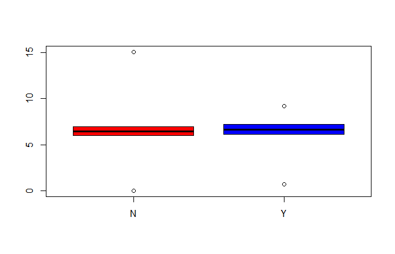

Fig. 2

```
## train$store_and_fwd_flag: N
##    Min. 1st Qu.  Median    Mean 3rd Qu.    Max.
##   0.000   5.984   6.495   6.464   6.979  15.076
## ------------------------------------------------------------
## train$store_and_fwd_flag: Y
##    Min. 1st Qu.  Median    Mean 3rd Qu.    Max.
##  0.6931  6.1203  6.6995  6.6274  7.2442  9.2087
```

## Worksheet with one variable

### Trip duration vs pickup_datetime using 20% of sampled data

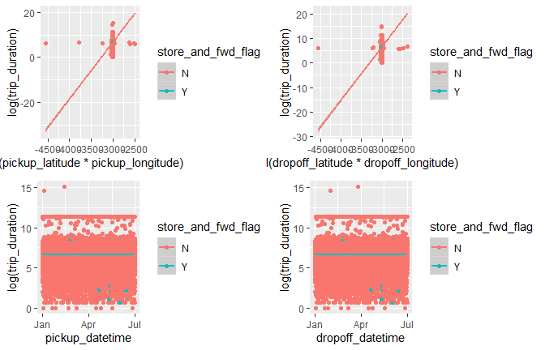

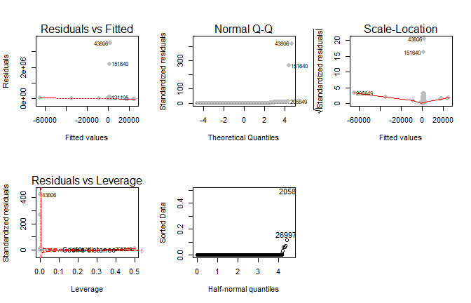

```
##
## Call:
## lm(formula = trip_duration ~ pickup_datetime:dropoff_datetime +
##     pickup_latitude:pickup_longitude + dropoff_latitude:dropoff_longitude +
##     store_and_fwd_flag)
##
## Residuals:
##     Min      1Q  Median      3Q     Max
##  -24343    -567    -306      95 3524589
##
## Coefficients:
##                                      Estimate Std. Error t value Pr(>|t|)
## (Intercept)                         1.274e+05  1.185e+04  10.750   <2e-16 ***
## store_and_fwd_flagY                 3.990e+01  2.136e+02   0.187    0.852
## pickup_datetime:dropoff_datetime    1.133e-15  1.197e-15   0.946    0.344
## pickup_latitude:pickup_longitude    4.681e+01  4.427e+00  10.574   <2e-16 ***
## dropoff_latitude:dropoff_longitude -4.078e+00  4.635e+00  -0.880    0.379
## ---
## Signif. codes:  0 '***' 0.001 '**' 0.01 '*' 0.05 '.' 0.1 ' ' 1
##
## Residual standard error: 8402 on 291724 degrees of freedom
## Multiple R-squared:  0.0005907,  Adjusted R-squared:  0.000577
## F-statistic: 43.11 on 4 and 291724 DF,  p-value: < 2.2e-16
```

```
##                                            0.5 %       99.5 %
## (Intercept)                         9.686831e+04 1.579209e+05
## store_and_fwd_flagY                -5.102422e+02 5.900486e+02
## pickup_datetime:dropoff_datetime   -1.951172e-15 4.217001e-15
## pickup_latitude:pickup_longitude    3.540824e+01 5.821617e+01
## dropoff_latitude:dropoff_longitude -1.601574e+01 7.860676e+00
```

[figure not shown]

#https://daviddalpiaz.github.io/appliedstats/inference-for-simple-linear-regression.html

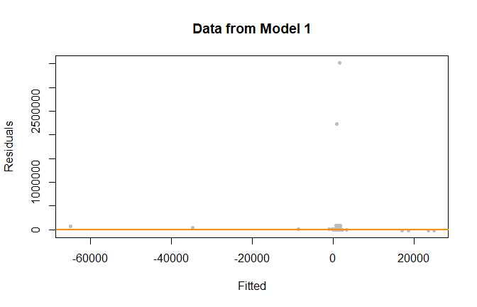

Breusch-Pagan Test.

H0: Homoscedasticity. The errors have constant variance about the true model. H1: Heteroscedasticity. The errors have non-constant variance about the true model.

```
##
##  studentized Breusch-Pagan test
##
## data:  sample_model
## BP = 16.662, df = 4, p-value = 0.002248
```

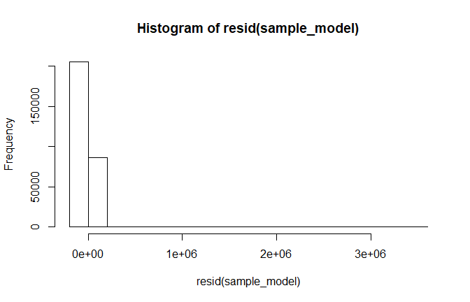

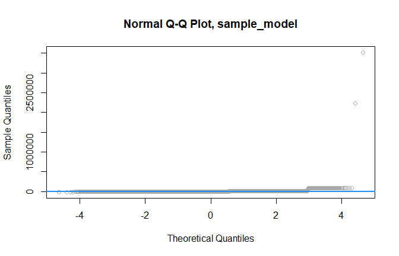

## Leverage

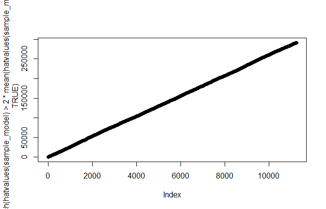

## Outliers

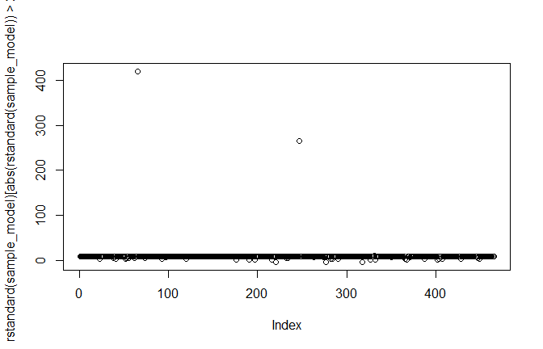

## Influence

```
##    11
## FALSE
```

## Coef change

```
## [1] 502
```

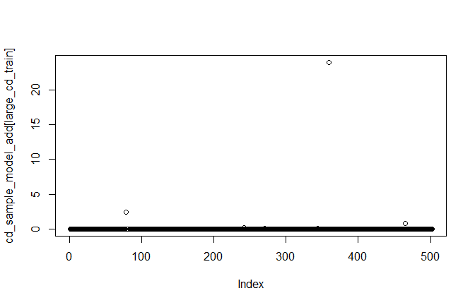

```
##                        (Intercept)                store_and_fwd_flagY
##                       1.273946e+05                       3.990318e+01
##   pickup_datetime:dropoff_datetime   pickup_latitude:pickup_longitude
##                       1.132915e-15                       4.681220e+01
## dropoff_latitude:dropoff_longitude
##                      -4.077534e+00
```

```
##       (Intercept) dropoff_longitude
##         81367.678          1086.988
```

### Transformations

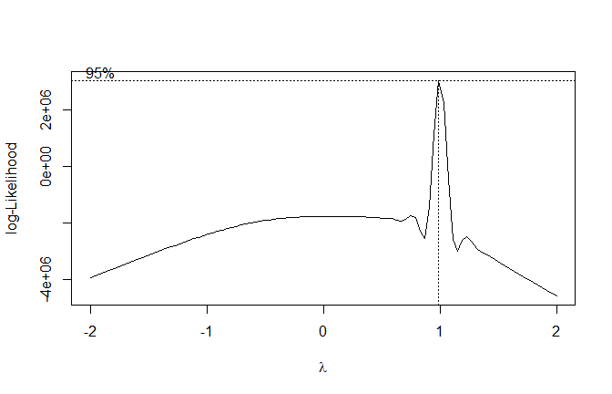

# Back to model

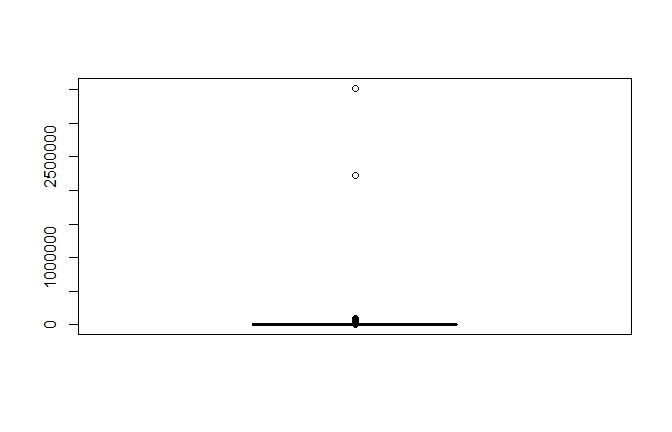

Fig. 2

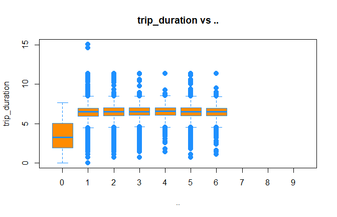

Fig. 2

vvvv positional information from kaggle vvvv

Finally, we will look at a simple overview visualisation of the *pickup/dropoff* latitudes and longitudes:

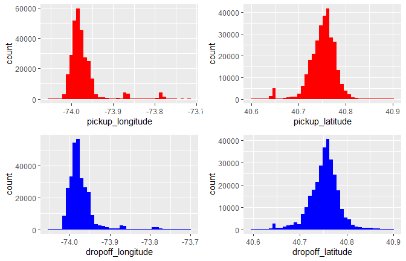

Fig. 6

# Feature relations by variable

# Feature engineering

New features to analyse

# Analyze dist, speed, time

## Bearing direction

# Data cleaning

# External data

Notes Kaggle

estimate of the *fastest routes for each trip* provided by oscarleo using the the Open Source Routing Machine, [OSRM](http://project-osrm.org/). The data can be found [here](https://www.kaggle.com/oscarleo/new-york-city-taxi-with-osrm) and includes the pickup/dropoff streets and total distance/duration between these two points together with a sequence of travels steps such as turns or entering a highway.

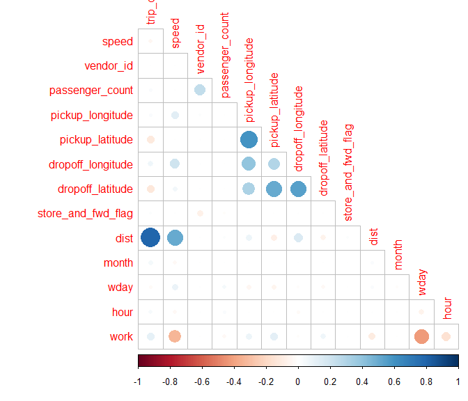

Fig. 30a

# An excursion into classification

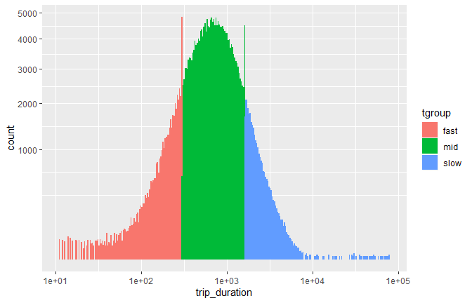

Fig. 31

(Ignore the apparent spikes caused by the binning resolution.)

For the purpose of this excercise, we are not interested in the middle bit. Our aim is to compare the properties of the fast vs slow trips.

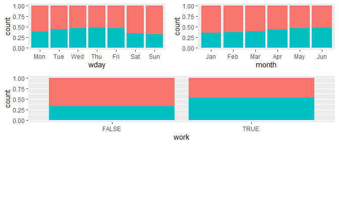

Fig. 32

I would like to thank retrospectprospect for introducing me to alluvial plots in their very elegant [EDA kernel](https://www.kaggle.com/retrospectprospect/titanic-machine-learning-from-eda-to-xgb) for the [Titanic](https://www.kaggle.com/c/titanic) challenge! The same user also has shared an informative and concise [kernel](https://www.kaggle.com/retrospectprospect/nyc-taxi-trip-duration-eda-to-xgb/) in this competition, and if you haven’t seen it yet then I definitely recommend you to check it out.

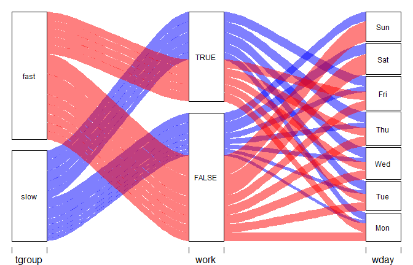

Fig. 34

# Model, correlation

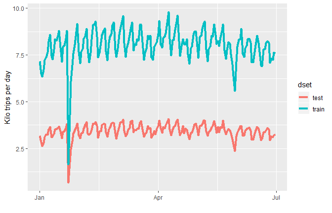

Fig. 35

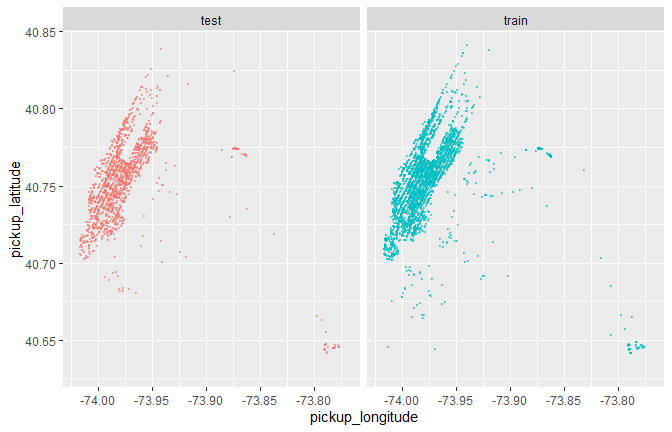

Fig. 36

### Data formatting

In this code block, the feature selection is structured with a little more detail than necessary, in order to make it easier to generalise it to a new problem:

```
## Observations: 2,083,778
## Variables: 18
## $ id                 <chr> "id2875421", "id2377394", "id3858529", "id350467...
## $ vendor_id          <int> 2, 1, 2, 2, 2, 2, 1, 2, 1, 2, 2, 2, 2, 2, 2, 1, ...
## $ pickup_datetime    <dttm> 2016-03-14 17:24:55, 2016-06-12 00:43:35, 2016-...
## $ dropoff_datetime   <dttm> 2016-03-14 17:32:30, 2016-06-12 00:54:38, 2016-...
## $ passenger_count    <int> 1, 1, 1, 1, 1, 6, 4, 1, 1, 1, 1, 4, 2, 1, 1, 1, ...
## $ pickup_longitude   <dbl> -73.98215, -73.98042, -73.97903, -74.01004, -73....
## $ pickup_latitude    <dbl> 40.76794, 40.73856, 40.76394, 40.71997, 40.79321...
## $ dropoff_longitude  <dbl> -73.96463, -73.99948, -74.00533, -74.01227, -73....
## $ dropoff_latitude   <dbl> 40.76560, 40.73115, 40.71009, 40.70672, 40.78252...
## $ store_and_fwd_flag <int> 1, 1, 1, 1, 1, 1, 1, 1, 1, 1, 1, 1, 1, 1, 1, 1, ...
## $ trip_duration      <int> 455, 663, 2124, 429, 435, 443, 341, 1551, 255, 1...
## $ dset               <fct> train, train, train, train, train, train, train,...
## $ dist               <dbl> 1500.1995, 1807.5298, 6392.2513, 1487.1625, 1189...
## $ date               <date> 2016-03-14, 2016-06-12, 2016-01-19, 2016-04-06,...
## $ month              <int> 3, 6, 1, 4, 3, 1, 6, 5, 5, 3, 5, 5, 2, 6, 5, 5, ...
## $ wday               <int> 3, 1, 4, 5, 2, 2, 7, 2, 7, 6, 4, 1, 7, 5, 7, 3, ...
## $ hour               <int> 17, 0, 11, 19, 13, 22, 22, 7, 23, 21, 22, 11, 9,...
## $ work               <int> 0, 0, 0, 0, 0, 0, 0, 0, 0, 0, 0, 0, 0, 0, 0, 0, ...
```

For our taxi challenge, the evaluation metric is [RMSLE](https://www.kaggle.com/c/nyc-taxi-trip-duration#evaluation), the [Root Mean Squared Logarithmic Error](https://www.kaggle.com/wiki/RootMeanSquaredLogarithmicError). Essentially, this means that we are optimising the prediction vs data deviations in log space. This has the advantage that large individual outliers don’t get as much weight as they would in a linear metric.

^^^ Kaggle ^^^

## Notes

New package corrr, FYI https://github.com/tidymodels/corrr

```
##
## Correlation method: 'pearson'
## Missing treated using: 'pairwise.complete.obs'
```

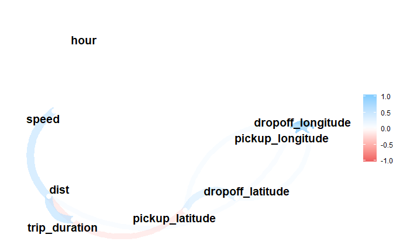

Interesting way to show stats https://cran.r-project.org/web/packages/broom/vignettes/broom.html

```
## # A tibble: 5 x 5
##   term                                estimate std.error statistic  p.value
##   <chr>                                  <dbl>     <dbl>     <dbl>    <dbl>
## 1 (Intercept)                         1.27e+ 5  1.19e+ 4    10.7   6.01e-27
## 2 store_and_fwd_flagY                 3.99e+ 1  2.14e+ 2     0.187 8.52e- 1
## 3 pickup_datetime:dropoff_datetime    1.13e-15  1.20e-15     0.946 3.44e- 1
## 4 pickup_latitude:pickup_longitude    4.68e+ 1  4.43e+ 0    10.6   3.99e-26
## 5 dropoff_latitude:dropoff_longitude -4.08e+ 0  4.63e+ 0    -0.880 3.79e- 1
```

```
## # A tibble: 291,729 x 15
##    trip_duration pickup_datetime     dropoff_datetime    pickup_latitude
##            <int> <dttm>              <dttm>                        <dbl>
##  1          1736 2016-05-07 09:08:05 2016-05-07 09:37:01            40.6
##  2           677 2016-06-05 21:06:51 2016-06-05 21:18:08            40.7
##  3           546 2016-03-25 04:08:02 2016-03-25 04:17:08            40.7
##  4           683 2016-02-16 14:38:26 2016-02-16 14:49:49            40.7
##  5           280 2016-04-18 00:02:51 2016-04-18 00:07:31            40.7
##  6           284 2016-03-11 06:49:30 2016-03-11 06:54:14            40.7
##  7          1602 2016-02-19 22:40:23 2016-02-19 23:07:05            40.8
##  8           498 2016-05-14 22:20:32 2016-05-14 22:28:50            40.7
##  9           607 2016-06-10 12:20:01 2016-06-10 12:30:08            40.8
## 10           909 2016-05-04 22:15:21 2016-05-04 22:30:30            40.8
## # ... with 291,719 more rows, and 11 more variables: pickup_longitude <dbl>,
## #   dropoff_latitude <dbl>, dropoff_longitude <dbl>, store_and_fwd_flag <chr>,
## #   .fitted <dbl>, .se.fit <dbl>, .resid <dbl>, .hat <dbl>, .sigma <dbl>,
## #   .cooksd <dbl>, .std.resid <dbl>
```

```
## # A tibble: 1 x 11
##   r.squared adj.r.squared sigma statistic  p.value    df  logLik    AIC    BIC
##       <dbl>         <dbl> <dbl>     <dbl>    <dbl> <int>   <dbl>  <dbl>  <dbl>
## 1  0.000591      0.000577 8402.      43.1 3.23e-36     5 -3.05e6 6.10e6 6.10e6
## # ... with 2 more variables: deviance <dbl>, df.residual <int>
```

Simple Outliers, Leverage and Model Diagnostics

https://daviddalpiaz.github.io/appliedstats/model-diagnostics.html

https://raw.githubusercontent.com/daviddalpiaz/appliedstats/master/diagnostics.Rmd

Analysis https://daviddalpiaz.github.io/appliedstats/transformations.html#r-markdown-7

COmbineing plots Haven’t used it, but might be easier https://indrajeetpatil.github.io/ggstatsplot/articles/web_only/combine_plots.html

# APPENDIX

**Code used in analysis**

```r
list.of.packages <- c("alluvial","caret","caret","corrplot","corrplot","data.table","dplyr","faraway","forcats","geosphere","ggplot2","ggplot2","ggplot2","grid","gridExtra","jtools","kableExtra","knitr","leaflet","leaflet.extras","leaps","lubridate","maps","MASS","mice","naniar","pander","patchwork","prettydoc","pROC","psych","RColorBrewer","readr","reshape2","scales","stringr","tibble","tidyr","tidyverse","xgboost","widgetframe","Rcpp")
new.packages <- list.of.packages[!(list.of.packages %in% installed.packages()[,"Package"])]
if(length(new.packages)) install.packages(new.packages)
require(knitr)
knitr::opts_chunk$set(echo = FALSE, warning = FALSE,fig.align='center')

library(faraway)
library(MASS)
library(psych)
library(pROC)
library(corrplot)
library(jtools)
library(mice)
library('corrr')
library(kableExtra)
library(gridExtra)
library(pander)
#devtools::install_github("thomasp85/patchwork")
library(patchwork)
library(tidyverse)
library(ggplot2)
library(ggplot2)
library(reshape2)
library(leaps)
library(caret)
library(naniar)
library('ggplot2') # visualisation
library('scales') # visualisation
library('grid') # visualisation
library('RColorBrewer') # visualisation
library('corrplot') # visualisation
library('alluvial') # visualisation
library('dplyr') # data manipulation
library('readr') # input/output
library('data.table') # data manipulation
library('tibble') # data wrangling
library('tidyr') # data wrangling
library('stringr') # string manipulation
library('forcats') # factor manipulation
library('lubridate') # date and time
library('geosphere') # geospatial locations
library('leaflet') # maps
library('leaflet.extras') # maps
library('maps') # maps
library('xgboost') # modelling
library('caret') # modelling
library('widgetframe') #visualizaiton
library('grid')
library('gridExtra')
# Define multiple plot function
#
# ggplot objects can be passed in ..., or to plotlist (as a list of ggplot objects)
# - cols:   Number of columns in layout
# - layout: A matrix specifying the layout. If present, 'cols' is ignored.
#
# If the layout is something like matrix(c(1,2,3,3), nrow=2, byrow=TRUE),
# then plot 1 will go in the upper left, 2 will go in the upper right, and
# 3 will go all the way across the bottom.
#

multiplot <- function(..., plotlist=NULL, file, cols=1, layout=NULL) {

  # Make a list from the ... arguments and plotlist
  plots <- c(list(...), plotlist)

  numPlots = length(plots)

  # If layout is NULL, then use 'cols' to determine layout
  if (is.null(layout)) {
    # Make the panel
    # ncol: Number of columns of plots
    # nrow: Number of rows needed, calculated from # of cols
    layout <- matrix(seq(1, cols * ceiling(numPlots/cols)),
                    ncol = cols, nrow = ceiling(numPlots/cols))
  }

 if (numPlots==1) {
    print(plots[[1]])
  } else {
    # Set up the page
    grid.newpage()
    pushViewport(viewport(layout = grid.layout(nrow(layout), ncol(layout))))

    # Make each plot, in the correct location
    for (i in 1:numPlots) {
      # Get the i,j matrix positions of the regions that contain this subplot
      matchidx <- as.data.frame(which(layout == i, arr.ind = TRUE))

      print(plots[[i]], vp = viewport(layout.pos.row = matchidx$row,
                                      layout.pos.col = matchidx$col))
    }
  }
}
var_stats<- function(df){
  wt<-data.frame(columns=colnames(df))
  wt$na_count <- sapply(df, function(y) sum(is.na(y)))
  wt$neg_count <- sapply(df, function(y) sum(y<0))
  wt$zero_count <- sapply(df, function(y) sum(as.integer(y)==0))
  wt$unique_count <- sapply(df, function(y) sum(n_distinct(y)))
  print(wt)
  return(wt)
}
train <- as_tibble(fread('data/train.csv'))
test <- as_tibble(fread('data/test.csv'))
sample_submit <- as_tibble(fread('data/sample_submission.csv'))
#str(train)
glimpse(train)
#summary(train)
#describe(train)
names(train)
names(test)
#glimpse(test)

#
vars_to_add <- train[!names(train) %in% names(test)]

 #vvvvv
## Combining train and test

combine <- rbind(train %>% mutate(dset = "train"),
                     test %>% mutate(dset = "test",
                                     dropoff_datetime = NA,
                                     trip_duration = NA))
combine <- combine %>% mutate(dset = factor(dset))
train <- train %>%
  mutate(pickup_datetime = ymd_hms(pickup_datetime),
         dropoff_datetime = ymd_hms(dropoff_datetime),
         vendor_id = factor(vendor_id),
         passenger_count = factor(passenger_count))
glimpse(combine)
var_stats(combine)

#ggplot(combine, aes(trip_duration)) +
#  geom__histogram(aes(y = ..density..)

attach(train)
boxplot(by(log(train$trip_duration),train$store_and_fwd_flag,summary),col=c("red","blue"))
by(log(train$trip_duration),train$store_and_fwd_flag,summary)

#plot(trip_duration ~ dropoff_longitude,pch  = 20,cex  = 2,col  = "grey")

sub_train = train%>%sample_frac(.2)
attach(sub_train)
g1<-ggplot(sub_train, aes(x=I(pickup_latitude*pickup_longitude), y=log(trip_duration), color = store_and_fwd_flag)) +geom_point() +stat_smooth(method="glm", se=TRUE)
g2<-ggplot(sub_train, aes(x=I(dropoff_latitude*dropoff_longitude), y=log(trip_duration), color = store_and_fwd_flag)) +geom_point() +stat_smooth(method="glm", se=TRUE)
g3<-ggplot(sub_train, aes(x=pickup_datetime, y=log(trip_duration), color = store_and_fwd_flag)) +geom_point() +stat_smooth(method="glm", se=TRUE)
g4<-ggplot(sub_train, aes(x=dropoff_datetime, y=log(trip_duration), color = store_and_fwd_flag)) +geom_point() +stat_smooth(method="glm", se=TRUE)
grid.arrange(g1, g2, g3, g4, ncol = 2)

sample_model = lm(trip_duration ~ pickup_datetime:dropoff_datetime+pickup_latitude:pickup_longitude+dropoff_latitude:dropoff_longitude+store_and_fwd_flag)

par(mfrow = c(2,3))
plot(sample_model,
     pch  = 20,
     cex  = 2,
     col  = "grey")
abline(sample_model, lwd = 3, col = "darkorange")
halfnorm(hatvalues(sample_model))

summary(sample_model)
confint(sample_model, level = 0.99)
trip_duration_grid = seq(min(trip_duration), max(trip_duration), by = 50)
dist_ci_band = predict(sample_model,
                       newdata = data.frame(speed = trip_duration_grid),
                       interval = "confidence", level = 0.99)
dist_pi_band = predict(sample_model,
                       newdata = data.frame(speed = trip_duration_grid),
                       interval = "prediction", level = 0.99)
```

```r
plot(trip_duration ~ dropoff_longitude,
     xlab = "Trip Duration",
     ylab = "Dropoff Logitude",
     main = "vs",
     pch  = 20,
     cex  = 2,
     col  = "grey",
     ylim = c(min(dist_pi_band), max(dist_pi_band)))
abline(sample_model, lwd = 5, col = "darkorange")

#lines(trip_duration_grid, dist_ci_band[,"lwr"], col = "dodgerblue", lwd = 3, lty = 2)
#lines(trip_duration_grid, dist_ci_band[,"upr"], col = "dodgerblue", lwd = 3, lty = 2)
#lines(trip_duration_grid, dist_pi_band[,"lwr"], col = "dodgerblue", lwd = 3, lty = 3)
#lines(trip_duration_grid, dist_pi_band[,"upr"], col = "dodgerblue", lwd = 3, lty = 3)
#points(mean(cars$dropoff_longitude), mean(train$trip_duration), pch = "+", cex = 3)


plot(fitted(sample_model), resid(sample_model), col = "grey", pch = 20,
     xlab = "Fitted", ylab = "Residuals", main = "Data from Model 1")
abline(h = 0, col = "darkorange", lwd = 2)



library(zoo)
library(lmtest)

bptest(sample_model)
hist(resid(sample_model))

qqnorm(resid(sample_model), main = "Normal Q-Q Plot, sample_model", col = "darkgrey")
qqline(resid(sample_model), col = "dodgerblue", lwd = 2)


#set.seed(42)
#shapiro.test(resid(sample_model))

plot(which(hatvalues(sample_model) > 2 * mean(hatvalues(sample_model)), TRUE))
plot(rstandard(sample_model)[abs(rstandard(sample_model)) > 2])
cooks.distance(sample_model)[11] > 4 / length(cooks.distance(sample_model))

cd_sample_model_add = cooks.distance(sample_model)
sum(cd_sample_model_add > 4 / length(cd_sample_model_add))


large_cd_train = cd_sample_model_add > 4 / length(cd_sample_model_add)
plot(cd_sample_model_add[large_cd_train])



coef(sample_model)
sample_model_add_fix = lm(trip_duration ~ dropoff_longitude,
                    data = train,
                    subset = cd_sample_model_add <= 4 / length(cd_sample_model_add))
coef(sample_model_add_fix)
mlm_model = lm(trip_duration ~ .-id-vendor_id-store_and_fwd_flag-trip_duration, data = sub_train)
boxcox(mlm_model, plotit = TRUE)
library(faraway)
pairs(sub_train, col = "dodgerblue")
#xx
fit_quad = lm(y ~ poly(trip_duration, degree = 2), data = poly_data)


sqrt(mean(resid(fit_quad) ^ 2))


calc_loocv_rmse = function(model) {
  sqrt(mean((resid(model) / (1 - hatvalues(model))) ^ 2))
}

calc_loocv_rmse(fit_quad)
sub_train$trip_duration %>% as.double() %>% boxplot()
#bins
#scale_x_log10() +
#scale_y_sqrt()
attach(sub_train)
boxplot(log(trip_duration) ~ as.factor(passenger_count),
     xlab   = "..",
     ylab   = "trip_duration",
     main   = "trip_duration vs ..",
     pch    = 20,
     cex    = 2,
     col    = "darkorange",
     border = "dodgerblue")

p1 <- sub_train %>%
  filter(pickup_longitude > -74.05 & pickup_longitude < -73.7) %>%
  ggplot(aes(pickup_longitude)) +
  geom_histogram(fill = "red", bins = 40)

p2 <- sub_train %>%
  filter(dropoff_longitude > -74.05 & dropoff_longitude < -73.7) %>%
  ggplot(aes(dropoff_longitude)) +
  geom_histogram(fill = "blue", bins = 40)

p3 <- sub_train %>%
  filter(pickup_latitude > 40.6 & pickup_latitude < 40.9) %>%
  ggplot(aes(pickup_latitude)) +
  geom_histogram(fill = "red", bins = 40)

p4 <- sub_train %>%
  filter(dropoff_latitude > 40.6 & dropoff_latitude < 40.9) %>%
  ggplot(aes(dropoff_latitude)) +
  geom_histogram(fill = "blue", bins = 40)

layout <- matrix(c(1,2,3,4),2,2,byrow=FALSE)
multiplot(p1, p2, p3, p4, layout=layout)
p1 <- 1; p2 <- 1; p3 <- 1; p4 <- 1

#jfk_coord <- tibble(lon = -73.778889, lat = 40.639722)

#la_guardia_coord <- tibble(lon = -73.872611, lat = 40.77725)


#train$jfk_dist_pick <- distCosine(pick_coord, jfk_coord)

#train$jfk_dist_drop <- distCosine(drop_coord, jfk_coord)

#train$lg_dist_pick <- distCosine(pick_coord, la_guardia_coord)

#train$lg_dist_drop <- distCosine(drop_coord, la_guardia_coord)



pick_coord <- sub_train %>% select(pickup_longitude, pickup_latitude)

drop_coord <- sub_train %>% select(dropoff_longitude, dropoff_latitude)

sub_train$dist <- distCosine(pick_coord, drop_coord)

#train$bearing = bearing(pick_coord, drop_coord)




sub_train <- sub_train %>%

  mutate(speed = dist/trip_duration*3.6,

         date = date(pickup_datetime),

         month = month(pickup_datetime, label = TRUE),

         wday = wday(pickup_datetime, label = TRUE),

         wday = fct_relevel(wday, c("Mon", "Tue", "Wed", "Thu", "Fri", "Sat", "Sun")),

         hour = hour(pickup_datetime),

         work = (hour %in% seq(8,18)) & (wday %in% c("Mon","Tue","Wed","Thu","Fri")),

 #        jfk_trip = (jfk_dist_pick < 2e3) | (jfk_dist_drop < 2e3),

 #       lg_trip = (lg_dist_pick < 2e3) | (lg_dist_drop < 2e3),

 #        blizzard = !( (date < ymd("2016-01-22") | (date > ymd("2016-01-29"))) )

         )


sub_train <- sub_train %>%

  filter(trip_duration < 22*3600,

         dist > 0 | (near(dist, 0) & trip_duration < 60),

#         jfk_dist_pick < 3e5 & jfk_dist_drop < 3e5,

         trip_duration > 10,

         speed < 100)


sub_train %>%

  select(-id, -pickup_datetime, -dropoff_datetime, -date) %>% #-jfk_dist_pick,

 #        -jfk_dist_drop, -lg_dist_pick, -lg_dist_drop, -date) %>%

  mutate(passenger_count = as.integer(passenger_count),

         vendor_id = as.integer(vendor_id),

         store_and_fwd_flag = as.integer(as.factor(store_and_fwd_flag)),

 #        jfk_trip = as.integer(jfk_trip),

         wday = as.integer(wday),

         month = as.integer(month),

         work = as.integer(work))%>%

 #        lg_trip = as.integer(lg_trip),

 #        blizzard = as.integer(blizzard),

 #        has_snow = as.integer(has_snow),

  #       has_rain = as.integer(has_rain)) %>%
#
  select(trip_duration, speed, everything()) %>%

  cor(use="complete.obs", method = "spearman") %>%

  corrplot(type="lower", method="circle", diag=FALSE)


train_group <- sub_train %>%

  mutate(tgroup = case_when(trip_duration < 3e2 ~ "fast",

                            trip_duration >= 3e2 & trip_duration <= 1.6e3 ~ "mid",

                            trip_duration > 1.6e3 ~ "slow"))



train_group %>%

  ggplot(aes(trip_duration, fill = tgroup)) +
```

```r
  geom_histogram(bins = 300) +

  scale_x_log10() +

  scale_y_sqrt()


train_group <- train_group %>%

  filter(tgroup != "mid")



p1 <- train_group %>%

  ggplot(aes(wday, fill = tgroup)) +

  geom_bar(position = "fill") +

  theme(legend.position = "none")



p2 <- train_group %>%

  ggplot(aes(month, fill = tgroup)) +

  geom_bar(position = "fill") +

  theme(legend.position = "none")



p3 <- train_group %>%

  ggplot(aes(hour, fill = tgroup)) +

  geom_bar(position = "fill")

p7 <- train_group %>%

  ggplot(aes(work, fill = tgroup)) +

  geom_bar(position = "fill") +

  theme(legend.position = "none")



layout <- matrix(c(1,1,2,2,3,3,3,3,4,5,6,7),3,4,byrow=TRUE)

multiplot(p1, p2,   p7, layout=layout)

p1 <- 1; p2 <- 1;   p7 <- 1


allu_train <- train_group %>%

  group_by(tgroup, work, wday) %>% # jfk_trip

  count() %>%

  ungroup



alluvial(allu_train %>% select(-n),

         freq=allu_train$n, border=NA,

         col=ifelse(allu_train$tgroup == "fast", "red", "blue"),

         cex=0.75,

         hide = allu_train$n < 150,

         ordering = list(

           order(allu_train$tgroup=="fast"),

       #    NULL,

           NULL,

           NULL))


foo <- combine %>%

  mutate(date = date(ymd_hms(pickup_datetime))) %>%

  group_by(date, dset) %>%

  count() %>%

  ungroup()

foo %>%

  ggplot(aes(date, n/1e3, color = dset)) +

  geom_line(size = 1.5) +

  labs(x = "", y = "Kilo trips per day")


pick_good <- combine %>%

  filter(pickup_longitude > -75 & pickup_longitude < -73) %>%

  filter(pickup_latitude > 40 & pickup_latitude < 42)

pick_good <- sample_n(pick_good, 5e3)



pick_good %>%

  ggplot(aes(pickup_longitude, pickup_latitude, color = dset)) +

  geom_point(size=0.1, alpha = 0.5) +

  coord_cartesian(xlim = c(-74.02,-73.77), ylim = c(40.63,40.84)) +

  facet_wrap(~ dset) +

  #guides(color = guide_legend(override.aes = list(alpha = 1, size = 4))) +

  theme(legend.position = "none")


# airport coordinates again, just to be sure

#jfk_coord <- tibble(lon = -73.778889, lat = 40.639722)

#la_guardia_coord <- tibble(lon = -73.872611, lat = 40.77725)



# derive distances

pick_coord <- combine %>%

  select(pickup_longitude, pickup_latitude)

drop_coord <- combine %>%

  select(dropoff_longitude, dropoff_latitude)

combine$dist <- distCosine(pick_coord, drop_coord)

#combine$bearing = bearing(pick_coord, drop_coord)



#combine$jfk_dist_pick <- distCosine(pick_coord, jfk_coord)

#combine$jfk_dist_drop <- distCosine(drop_coord, jfk_coord)

#combine$lg_dist_pick <- distCosine(pick_coord, la_guardia_coord)

#combine$lg_dist_drop <- distCosine(drop_coord, la_guardia_coord)



# add dates

combine <- combine %>%

  mutate(pickup_datetime = ymd_hms(pickup_datetime),

         dropoff_datetime = ymd_hms(dropoff_datetime),

         date = date(pickup_datetime)

  )



# add weather info

#foo <- weather %>%

#  select(date, rain, s_fall, all_precip, has_snow, has_rain, s_depth, max_temp, min_temp)

#combine <- left_join(combine, foo, by = "date")






# reformat to numerical and recode levels

combine <- combine %>%

  mutate(store_and_fwd_flag = as.integer(factor(store_and_fwd_flag)),

         vendor_id = as.integer(vendor_id),

         month = as.integer(month(pickup_datetime)),

         wday = wday(pickup_datetime, label = TRUE),

         wday = as.integer(fct_relevel(wday, c("Sun", "Sat", "Mon", "Tue", "Wed", "Thu", "Fri"))),

         hour = hour(pickup_datetime),

         work = as.integer( (hour %in% seq(8,18)) & (wday %in% c("Mon","Tue","Fri","Wed","Thu")) ),

#         jfk_trip = as.integer( (jfk_dist_pick < 2e3) | (jfk_dist_drop < 2e3) ),
#
#         lg_trip = as.integer( (lg_dist_pick < 2e3) | (lg_dist_drop < 2e3) ),

#         has_rain = as.integer(has_rain),

#         has_snow = as.integer(has_snow),

#         blizzard = as.integer( !( (date < ymd("2016-01-22") | (date > ymd("2016-01-29")))) )

         )


# Specific definitions:

#---------------------------------

# predictor features

train_cols <- c("total_distance", "hour", "dist",

                "vendor_id",
                #"jfk_trip", "lg_trip",
                "wday", "month",

                "pickup_longitude", "pickup_latitude"
                #, "bearing", "lg_dist_drop"
                )

# target feature

y_col <- c("trip_duration")

# identification feature

id_col <- c("id")

# auxilliary features

aux_cols <- c("dset")

# cleaning features

#clean_cols <- c("jfk_dist_drop", "jfk_dist_pick")

#---------------------------------



# General extraction

#---------------------------------

# extract test id column

#test_id <- combine %>%

#  filter(dset == "test") %>%

#  select_(.dots = id_col)



# all relevant columns for train/test

#names(combine) <- c(train_cols, y_col, aux_cols)#, clean_cols)


glimpse(combine)
library(corrr)
ssub_train<-sub_train[sapply(sub_train, function(x) is.numeric(x) && !is.na(x))]

ssub_train %>%
  correlate() %>%
  network_plot(min_cor = .2)
library(broom)

tidy(sample_model)
augment(sample_model)
glance(sample_model)
```